# VL06: Entscheidungsbäume: CAL2, Pruning

IFM 5.6 Künstliche Intelligenz, 2017/18

Carsten Gips, FH Bielefeld

# Wiederholung

## Constraintsolving

- Definieren Sie in eigenen Worten die Begriffe:
  1. Constraint
  2. CSP
  3. Lösung eines CSP
- Warum müssen bei AC-3 nach dem Entfernen von Werten aus der Domäne einer Variablen alle Constraints von anderen Variablen zu der aktuell betrachteten Variable erneut untersucht werden?

# Motivation

## Was für ein Zusammenhang ist hier dargestellt?

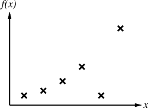

Quelle: [AIMA 3rd ed.](http://aima.cs.berkeley.edu)

## Themen für heute

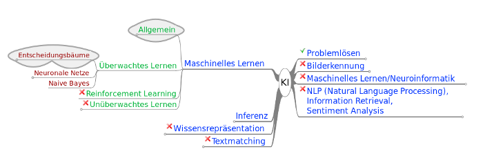

Am Ende der VL können/verstehen Sie:

- Was ist Maschinelles Lernen?
- Was sind Merkmalsvektoren?
- Was sind Entscheidungsbäume?
- Einfacher Entscheidungsbaum-Lerner: CAL2

# Maschinelles Lernen

## Was ist Lernen?

> Verhaltensänderung eines Agenten in Richtung der Optimierung eines Gütefunktionals (Bewertungsfunktion) durch Erfahrung.

## Warum Lernen?

- Nicht alle Situationen vorhersehbar
- Nicht alle Details modellierbar
- Lösung(sweg) unbekannt, nicht explizit programmierbar
- Data Mining: Entdeckung neuen Wissens durch Analyse der Daten
- Selbstanpassende Programme

=> Lernen wichtige Eigenschaft lebender Wesen :-)

## Learning Agent

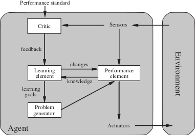

Quelle: [AIMA 3rd ed.](http://aima.cs.berkeley.edu)

## Feedback während des Lernens

- **Überwachtes Lernen**
  - Lernen durch Beobachtung
  - Vorgabe von Beispielen: Ein- und Ausgabewerte

  => Regression, Klassifikation
- **Unüberwachtes Lernen**
  - Erkennen von Mustern in den Inputdaten, Clustering
  - Kein Feedback (!)
- **Reinforcement Lernen**
  - Bewertung der Aktionen des Agenten am Ende einer Aktionsfolge

Analogie Lernen beim Kleinkind

## Beispiel: Kreditrisiko

- Bankkunde beantragt Kredit
- Soll er aus Sicht der Bank den Kredit bekommen?
- Bankangestellter betrachtet (relevante) Merkmale des Kunden:
  - Alter, Einkommen, sozialer Status
  - Kundenhistorie bei der Bank
  - Höhe des Kredits

## Beispiel: Kreditrisiko (cnt.)

- Bewertung des Kreditrisikos:
  - **Klassifikation**: Guter oder schlechter Kunde (Binäre Entscheidung: 2 Klassen)
  - **Regression**: Vorhersage Gewinn/Verlust für die Bank (Höhe des Gewinns/Verlusts interessant)
- Bewertung soll verbessert/angepasst werden:
  - Vorgabe von Kundenbeschreibungen und Bewertung aus der Vergangenheit
  - Lernen: Anpassung der internen Regeln, Bewertungen, …
  - Anwendung: Bessere Vorhersage für neue Kunden

## Beispiel: Autoreparatur

- **Gegeben**: Eigenschaften eines Autos

  => Eigenschaften: Ausprägungen der Merkmale
- **Gesucht**: Diagnose und Reparaturanleitung

  => Funktion $\operatorname{h}$ über den Merkmalen (Hypothese)

## Lernen durch Beobachten: Lernen einer Funktion $\operatorname{f}$

Funktionsapproximation: Lernen einer Funktion $\operatorname{f}$ anhand von Beispielen

- Ein Beispiel ist ein Tupel $\left(x, \operatorname{f}(x)\right)$, etwa $\left(\begin{array}{ccc} \text{O}&\text{O}&\text{X} \\ \text{.}&\text{X}&\text{.} \\ \text{X}&\text{.}&\text{.} \end{array}\;\;,\;\; +1\right)$
- Aufgabe: Baue Hypothese $\operatorname{h}$ auf, so dass $\operatorname{h} \approx \operatorname{f}$.
  - Benutze dazu Menge von Beispielen => Trainingsdaten .
- Ziele:
  1. **Konsistente Hypothese**: Übereinstimmung bei Trainingsdaten
  2. **Generalisierende Hypothese**: Korrekte Vorhersage bei unbekannten Daten

*Anmerkung*: Stark vereinfachtes Modell realen Lernens!

## Konstruieren einer konsistenten Hypothese

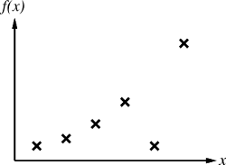

Quelle: [AIMA 3rd ed.](http://aima.cs.berkeley.edu)

## Konstruieren einer konsistenten Hypothese (cnt.)

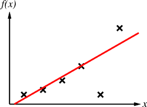

Quelle: [AIMA 3rd ed.](http://aima.cs.berkeley.edu)

## Konstruieren einer konsistenten Hypothese (cnt.)

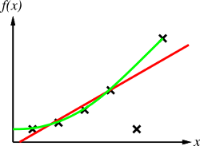

Quelle: [AIMA 3rd ed.](http://aima.cs.berkeley.edu)

## Konstruieren einer konsistenten Hypothese (cnt.)

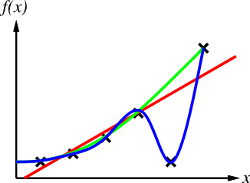

Quelle: [AIMA 3rd ed.](http://aima.cs.berkeley.edu)

## Konstruieren einer konsistenten Hypothese (cnt.)

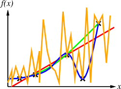

Quelle: [AIMA 3rd ed.](http://aima.cs.berkeley.edu)

## Ockham’s Razor

**Bevorzuge die einfachste konsistente Hypothese!**

1. Wenn es mehrere mögliche Erklärungen für einen Sachverhalt gibt, ist die einfachste Erklärung allen anderen vorzuziehen.
2. Eine Erklärung ist “einfach”, wenn sie möglichst wenige Variablen und Annahmen enthält und wenn diese in klaren logischen Beziehungen zueinander stehen, aus denen der zu erklärende Sachverhalt logisch folgt.

## Trainingsdaten

Lehrer gibt Beispiele vor: Eingabe und passende Ausgabe

- Ausgabe: typischerweise Skalar (Funktionswert oder Klasse) => Beispiel: Bewertung eines Spielstandes bei TicTacToe
- Eingabe: Objekt oder Situation, die zur Ausgabe gehört => Beispiel: Spielstand bei TicTacToe

**Merkmalsvektoren**:

- Zusammenfassen der relevanten Merkmale zu Vektoren

## Beispiel: Schwimmen im See

| Beispiel | Himmel | Lufttemp. | Wassertemp. | Wind | Schwimmen? |
| --- | --- | --- | --- | --- | --- |
| 1 | sonnig | warm | warm | windstill | ja |
| 2 | sonnig | kalt | warm | stürmisch | nein |
| 3 | sonnig | warm | warm | brise | ja |
| 4 | bewölkt | kalt | kalt | windstill | nein |
| 5 | regen | kalt | warm | windstill | ja |

- Trainingsbeispiel 1:
  - Eingabe: Merkmalsvektor `(sonnig, warm, warm, windstill)`
  - Ausgabe: Klasse `ja`

## Trainingsdaten – Merkmalsvektoren

**Generell**: Merkmalsvektor für Objekt $v$:
$$\mathbf{x}(v) = (x_1, x_2, \ldots, x_n)$$

- $n$ Merkmale (Attribute)
- Attribut $x_t$ hat $m_t$ mögliche Ausprägungen
- Ausprägung von $v$ bzgl. $x_t$: $\quad x_t(v) = i \quad$ (mit $i = 1 \ldots m_t$)

**Trainingsbeispiel**:

- Tupel aus Merkmalsvektor und zugehöriger Klasse: $\left(\mathbf{x}(v), k\right)$

# Entscheidungsbäume: CAL2

## Entscheidungsbäume: Klassifikation

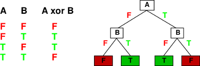

Quelle: [AIMA 3rd ed.](http://aima.cs.berkeley.edu)

- Attribute als Knoten im Baum
- Ausprägungen als Test (Ausgang, Verzweigung)
- Klasse (Funktionswert) als Blatt

Erinnern Sie sich an das Beispiel mit der Auto-Reparatur.

Die relevanten Eigenschaften (Merkmale) eines Autos würden als Knoten im Baum repräsentiert. Beispiel: “Motor startet” oder “Farbe”.

Jedes Merkmal hat eine Anzahl von möglichen Ausprägungen, diese ensprechen den Verzweigungen am Knoten. Beispiel: “startet”, “startet nicht” oder “rot”, “weiß”, “silber”, … .

Entsprechend kann man durch Abarbeiten des Entscheidungsbaumes am Ende zu einer Diagnose gelangen (Klasse).

Eine andere Sichtweise ist die Nutzung als Checkliste für eine Reparatur …

## Definition Entscheidungsbaum

- Erinnerung: **Merkmalsvektor** für Objekt $v$:
  $$\mathbf{x}(v) = (x_1, x_2, \ldots, x_n)$$
  - $n$ Merkmale (Attribute)
  - Attribut $x_t$ hat $m_t$ mögliche Ausprägungen
  - Ausprägung von $v$ bzgl. $x_t$: $\quad x_t(v) = i \quad$ (mit $i = 1 \ldots m_t$)
- **Alphabet** für Baum:
  $$\{x_t |\; t=1,\ldots,n\} \cup \{\kappa |\; \kappa = *,A,B,C,\ldots\} \cup \{(,)\}$$
- **Entscheidungsbaum** $\alpha$:
  $$\alpha = \left\{ \begin{array}{ll}
  \kappa & \text{Terminalsymbole: } \kappa = *,A,B, \ldots\\
  x_t(\alpha_1, \alpha_2, \ldots, \alpha_{m_t}) & x_t \text{ Testattribut mit } m_t \text{ Ausprägungen}
  \end{array}\right.$$

Tafelbeispiel mit XOR

## Induktion von Entscheidungsbäumen: CAL2

1. Anfangsschritt: $\alpha^{(0)} = *$ (totales Unwissen)
2. $n$-ter Lernschritt: Objekt $v$ mit Klasse $k$, Baum $\alpha^{(n-1)}$ gibt $\kappa$ aus
   1. $\kappa = *$: ersetze $*$ durch $k$
   2. $\kappa = k$: keine Aktion nötig
   3. $\kappa \neq k$: Fehler
      - Ersetze $\kappa$ mit neuem Test: $\kappa \gets x_{t+1}(*, \ldots, *, k, *, \ldots, *)$
      - $x_{t+1}$: nächstes Attribut, auf dem aktuellen Pfad noch nicht verwendet
      - Symbol $k$ an Position $i$ wenn $x_{t+1}(v) = i$

$\alpha^{(n)}$ bezeichnet den Baum im $n$-ten Lernschritt.

CAL2 ist ein *Meta-Algorithmus*: Es ist ein Algorithmus, um einen Algorithmus zu lernen :-)

## Beispiel mit CAL2

| $x_1$ | $x_2$ | $x_3$ | $k$ |
| --- | --- | --- | --- |
| 0 | 0 | 1 | A |
| 1 | 0 | 0 | A |
| 0 | 1 | 4 | B |
| 1 | 1 | 2 | B |
| 0 | 0 | 3 | A |

Tafelbeispiel CAL2

**Ergebnis**: $x_1\left(x_2(A, B), \; x_2(A, B)\right)$

## CAL2: Bemerkungen

- Nur für diskrete Merkmale und disjunkte Klassen
- Zyklischer Durchlauf durch Trainingsmenge
- Abbruch:
  - Alle Trainingsobjekte richtig klassifiziert => Kein Fehler in einem kompletten Durchlauf
  - Differenzierung nötig, aber alle Merkmale verbraucht
  - Lernschrittzahl überschritten

## Pruning: Bedingt irrelevante Attribute

**Baum**: $\alpha = x_1\left(x_2(A, B), \; x_2(A, B), \; x_2(A, B)\right)$

$x_1$ ist bedingt irrelevant => Vereinfachung: $\alpha = x_2\left(A, B\right)$

**Allgemein**:

- Sei $\tilde{x}$ Weg zu Nichtendknoten $x_t$
- Baum dort $\alpha/\tilde{x} = x_t(\alpha_1, \ldots, \alpha_{m_t})$
- $x_t$ ist bedingt irrelevant unter der Bedingung $\tilde{x}$, wenn $\alpha_1 = \alpha_2 = \ldots = \alpha_{m_t}$
- **Vereinfachung**: Ersetze in $\alpha/\tilde{x}$ den Test $x_t$ durch $\alpha_1$

*Anmerkung*: Der durch das Entfernen von bedingt irrelevanten Attributen entstandene Baum hat exakt die selbe Aussage (Klassifikation) wie der Baum vor dem Pruning.

## Pruning: Bedingt redundante Attribute

**Baum**: $\alpha = x_1\left(*, \; *, \; x_2(A, B)\right)$

$x_1$ ist bedingt redundant => Vereinfachung: $\alpha = x_2\left(A, B\right)$

**Allgemein**:

- Sei $\tilde{x}$ Weg zu Nichtendknoten $x_t$
- Baum dort $\alpha/\tilde{x} = x_t(*, \ldots, *, \alpha_i, *, \ldots, *)$ (mit $\alpha_i \neq *$)
- $x_t$ ist bedingt redundant unter der Bedingung $\tilde{x}$
- **Vereinfachung**: Ersetze in $\alpha/\tilde{x}$ den Test $x_t$ durch $\alpha_i$

*Anmerkung*: Der durch das Entfernen von bedingt redundanten Attributen entstandene Baum hat eine etwas andere Klassifikation als der Baum vor dem Pruning. Wo vorher ein `*` ausgegeben wurde, wird nach dem Pruning u.U. ein Klassensymbol ausgegeben. Der Klassifikationsfehler erhöht sich nicht, da hier ein `*` wie ein falsches Klassensymbol zu werten ist.

## Allgemeine Transformationsregel

$$x_1(x_2(a, b), \; x_2(c, d)) \; \Leftrightarrow \; x_2(x_1(a, c), \; x_1(b, d))$$

# Zusammenfassung

## tl;dr

- Lernen ist Verhaltensänderung, Ziel: Optimierung einer Gütefunktion
  - Aufbau einer Hypothese, die beobachtete Daten erklären soll
  - Arten: Überwachtes Lernen, Unüberwachtes Lernen, Reinforcement Lernen
- Merkmalsvektoren gruppieren Eigenschaften des Problems
- Trainingsdaten: Beispielobjekte (durch Merkmalsvektoren beschrieben) plus Vorgabe vom Lehrer
- Darstellung der Hypothese als Entscheidungsbaum
- CAL2: diskrete Attribute, disjunkte Klassen
- Pruning: Entfernen redundanter und irrelevanter Tests
- Transformationsregel zum Umbauen von Entscheidungsbäumen

**Nächste Woche**: Entscheidungsbäume: CAL3, ID3

## Literatur zum Weiterlesen

- Russell, Norvig: “Artificial Intelligence: A Modern Approach, 3rd ed.”
  - Lernen, Entscheidungsbäume: Abschnitt 18.1, 18.2 und 18.3
- Unger, Wysotzki: “Lernfähige Klassifizierungssysteme (Classifier Systems Which Are Able to Learn)”, Akademie-Verlag, Berlin, 1981.

## Lernziele – Nach dieser Vorlesung sollten Sie …

### Kennen (K1)

- Definition und Arten des Lernens

### Verstehen (K2)

- Überwachtes Lernen: Lernen durch Beobachten (mit Lehrer)
- Merkmalsvektoren, Eigenschaften, Ausprägung, Objekte, Trainingsmenge

### Anwenden (K3)

- Entscheidungsbaumlerner CAL2
- Pruning: Entfernen bedingt irrelevanter Tests
- Pruning: Entfernen bedingt redundanter Tests
- Umformen von Entscheidungsbäumen mit Transformationsregel

## Diese Fragen sollten Sie beantworten können …

### Lernen: Begriffe und Grundlagen

- Welche Formen des Feedbacks beim Lernen gibt es?
- Was bedeutet überwachtes Lernen?
- Was ist eine Trainingsmenge, was ein Merkmalsvektor?
- Überlegen Sie sich den Aufbau des Merkmalvektors sowie einige Trainingsdaten für das Problem *“Soll ich einen Schirm mitnehmen?”*
- Überlegen Sie sich selbst ein Problem und den zugehörigen Merkmalsvektor.

### Entscheidungsbäume: CAL2

- Führen Sie eine Handsimulation von CAL2 mit folgender Trainingsmenge durch:

  | $x_1$ | $x_2$ | $k$ |
  | --- | --- | --- |
  | 0 | 0 | 0 |
  | 0 | 1 | 0 |
  | 1 | 0 | 1 |
  | 1 | 1 | 1 |

- Vereinfachen Sie den Baum $x_3(x_2(x_1(C,A), \;x_1(B,A)), \;\; x_1(x_2(C,B), \; A))$.
- Was geschieht, wenn CAL2 auf eine Trainingsmenge mit überlappenden Klassen angewendet wird?